# Police_shooting

## Analysing Fatal shootings By Police in United States

### The FBI and the Centers for Disease Control and Prevention log fatal shootings by police, but officials acknowledge that their data is incomplete. In 2015, The Post documented more than two times more fatal shootings by police than had been recorded by the FBI. Last year, the FBI announced plans to overhaul how it tracks fatal police encounters.

### Source- Kaggle Police shooting dataset (https://www.kaggle.com/mrmorj/data-police-shootings)

By:- Aditya Srichandan

```python
import pandas as pd
import numpy as np
import matplotlib.pyplot as plt
import seaborn as sns
import matplotlib.ticker as ticker
import plotly.offline as py
import plotly.graph_objs as go
import plotly.express as px
import plotly.tools as tls
import plotly.figure_factory as ff
```

```python
data=pd.read_csv('Data/fatal-police-shootings-data.csv')
data.head(10)
```

|  | id | name | date | manner_of_death | armed | age | gender | race | city | state | signs_of_mental_illness | threat_level | flee | body_camera |
| --- | --- | --- | --- | --- | --- | --- | --- | --- | --- | --- | --- | --- | --- | --- |
| 0 | 3 | Tim Elliot | 2015-01-02 | shot | gun | 53.0 | M | A | Shelton | WA | True | attack | Not fleeing | False |
| 1 | 4 | Lewis Lee Lembke | 2015-01-02 | shot | gun | 47.0 | M | W | Aloha | OR | False | attack | Not fleeing | False |
| 2 | 5 | John Paul Quintero | 2015-01-03 | shot and Tasered | unarmed | 23.0 | M | H | Wichita | KS | False | other | Not fleeing | False |
| 3 | 8 | Matthew Hoffman | 2015-01-04 | shot | toy weapon | 32.0 | M | W | San Francisco | CA | True | attack | Not fleeing | False |
| 4 | 9 | Michael Rodriguez | 2015-01-04 | shot | nail gun | 39.0 | M | H | Evans | CO | False | attack | Not fleeing | False |
| 5 | 11 | Kenneth Joe Brown | 2015-01-04 | shot | gun | 18.0 | M | W | Guthrie | OK | False | attack | Not fleeing | False |
| 6 | 13 | Kenneth Arnold Buck | 2015-01-05 | shot | gun | 22.0 | M | H | Chandler | AZ | False | attack | Car | False |
| 7 | 15 | Brock Nichols | 2015-01-06 | shot | gun | 35.0 | M | W | Assaria | KS | False | attack | Not fleeing | False |
| 8 | 16 | Autumn Steele | 2015-01-06 | shot | unarmed | 34.0 | F | W | Burlington | IA | False | other | Not fleeing | True |
| 9 | 17 | Leslie Sapp III | 2015-01-06 | shot | toy weapon | 47.0 | M | B | Knoxville | PA | False | attack | Not fleeing | False |

```python
data.info()
```

```
<class 'pandas.core.frame.DataFrame'>
RangeIndex: 5416 entries, 0 to 5415
Data columns (total 14 columns):
 #   Column                   Non-Null Count  Dtype
---  ------                   --------------  -----
 0   id                       5416 non-null   int64
 1   name                     5416 non-null   object
 2   date                     5416 non-null   object
 3   manner_of_death          5416 non-null   object
 4   armed                    5189 non-null   object
 5   age                      5181 non-null   float64
 6   gender                   5414 non-null   object
 7   race                     4895 non-null   object
 8   city                     5416 non-null   object
 9   state                    5416 non-null   object
 10  signs_of_mental_illness  5416 non-null   bool
 11  threat_level             5416 non-null   object
 12  flee                     5167 non-null   object
 13  body_camera              5416 non-null   bool
dtypes: bool(2), float64(1), int64(1), object(10)
memory usage: 518.5+ KB
```

#### Lets look at the features column of the dataset

1. id ----------------------------- refers to person Id
2. name --------------------------- Name of the victim
3. date --------------------------- date the particular victim was shot
4. manner_of_death ---------------- cause of death
5. armed -------------------------- victim armed with weapon?
6. age ---------------------------- age of the victim
7. gender ------------------------- gender of the victim
8. race --------------------------- ethnicity of the victim
9. city --------------------------- city where the victim was shot by the police
10. state ------------------------- state where the victim was shot by the police
11. signs_of_mental_illness-------- if the victim showed any signs of mental illness (Y/N)
12. threat_level ------------------ how dangerous the victim was
13. flee -------------------------- was the victim trying to escape?
14. body_camera ------------------- if the police had a body camera on them?

### Some Questions to ask while analysing the shootings (CRISP DM)

#### I am using the dataset to find insights on how shootings are distributed among the various features.

1. Analyse shooting w.r.t age and race of the victim?
2. Was the police shooting based on self defence or intended?
3. Cities with more shooting rate ?
4. How did mental illness and threat level of victim affected the brutal shootings?

```python
# Lets see if the data contains any null values
print(data.isnull().sum())

#total samples of data
print("\n","samples", ":", data.shape[0])

#total Null Values=1234
```

```
id                           0
name                         0
date                         0
manner_of_death              0
armed                      227
age                        235
gender                       2
race                       521
city                         0
state                        0
signs_of_mental_illness      0
threat_level                 0
flee                       249
body_camera                  0
dtype: int64

 samples : 5416
```

```python
def missing_values(data):
    """
    Description: The function uses dataframe input, will compute any missing values and plot it

    Arguments:
        data: Pandas Dataframe for missing values

    Returns:
        None
    """

    null = pd.DataFrame(data.shape[0] - data.isnull().sum(), columns = ['Count'])
    ax=null.plot(kind='bar',figsize=(10,10))

    for p in ax.patches:
        val=100.0-p.get_height()/data.shape[0]*100
        val=str(val.round(2))+"%"
        ax.annotate(val, (p.get_x() * 1.005, p.get_height() * 1.005))
    plt.show();
```

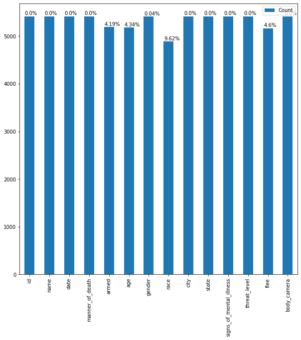

```python
missing_values(data)
```

#### We can see these are the missing values in the data.

1. armed (227) -- 4.19%
2. age (235) -- 4.34%
3. gender (2) -- 0.04%
4. race (521) -- 9.62%
5. flee (249) -- 4.60%

##### since very less data has null values as well as it would not much contribute to the overall analysis, hence I choose to drop the null values

a dataset having over 5K rows dropping them would not necessarily harm any analysis of the data

```python
#null value of the features
data.isnull().apply(pd.value_counts)
missing = [(col_name, ((data[col_name].isnull().sum())/data[col_name].value_counts().sum())*100) for col_name in data.columns if data[col_name].isnull().any() == True]
print(missing)
data=data.dropna()
```

```
[('armed', 4.374638658701099), ('age', 4.535803898861223), ('gender', 0.03694126339120798), ('race', 10.643513789581204), ('flee', 4.819043932649506)]
```

```python
#seperating month and year.
data['month'] = pd.to_datetime(data['date']).dt.month
data['year'] = pd.to_datetime(data['date']).dt.year
```

## Analyse the shooting w.r.t age, race and gender of the victim.

```python
# first lets look at how gender is distributed in the shootings
gender=data.groupby(['year','gender']).agg('count')['id'].to_frame(name='count').reset_index()
gender_male=gender.loc[gender['gender']=='M']
gender_female=gender.loc[gender['gender']=='F']
gender_female
```

|  | year | gender | count |
| --- | --- | --- | --- |
| 0 | 2015 | F | 35 |
| 2 | 2016 | F | 35 |
| 4 | 2017 | F | 34 |
| 6 | 2018 | F | 42 |
| 8 | 2019 | F | 37 |
| 10 | 2020 | F | 14 |

```python
def gender_wise_killings(data):
    """
    Description: The function uses dataframe of gender and year features as input, and outputs a bar plot.

    Arguments:

    data: Pandas Dataframe to impute gender wise killings.

    Returns:
        None
    """
    male=go.Bar(x=data[0]['year'],y=data[0]['count'],marker=dict(color='red'),name="male")

    female=go.Bar(x=data[1]['year'],y=data[1]['count'],marker=dict(color='blue'),name="female")

    gen=[male,female]

    fig = go.Figure(gen)

    fig.update_xaxes(showline=True, linewidth=2, linecolor='black', mirror=True)
    fig.update_yaxes(showline=True, linewidth=2, linecolor='black', mirror=True)
    fig.update_layout(title="Shootings- Gender",xaxis=dict(title="Year"),yaxis=dict(title="Counts"),barmode="group")
    fig.show()
```

```python
gender_wise_killings(data=[gender_male,gender_female])
```

[interactive chart not shown]

```python
print("Shootings of gender F:M = 1:{}".format(round(gender_male['count'].mean()/gender_female['count'].mean())))
```

```
Shootings of gender F:M = 1:21
```

## Most affected age group

```python
drop_vals=data['age'].dropna()
hist_data = [drop_vals]
group_labels = ['Age']
colors=["orange"]
fig=go.Figure()
fig=ff.create_distplot(hist_data, group_labels,bin_size=5,colors=colors)
fig.update_layout(title_text="Distribution of Age",title_x=0.5)
fig.show()
```

[interactive chart not shown]

## Most affected race

```python
race_kill = data[['year','race']]
race_kill ['kills'] =1
race_kill  = race_kill.groupby(['year','race']).sum()
race_kill = race_kill.reset_index()
fig = px.bar(race_kill , y='kills', x='year',color='race', barmode='group')
fig.show()
```

[interactive chart not shown]

#### A - Asian, W - White, H - Hispanic, B - Black, O - Others, N - Native are different races.

It is evident from the graph White people are most to be shot down by the police followed by Black race over a span of 5 years.

```
Average Deaths per month: 66.65151515151516
Standard deviation Deaths per month: 13.189174192728446
Average Deaths per Year (not including 2020): 733.1666666666666
Standard deviation Deaths per year: 182.33340950638265
```

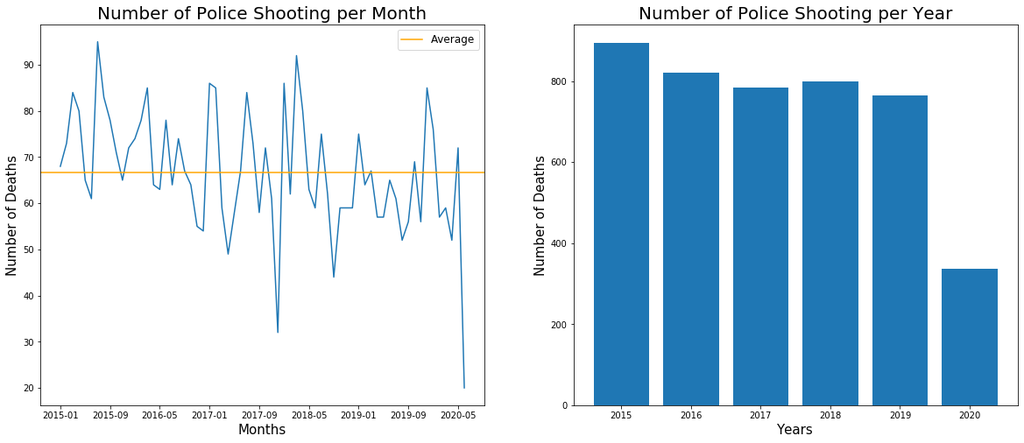

```python
#Lets find the deaths in time
x_months = [0]
y_months = [0]
x_year = [0]
y_year = [0]
temp = 0
for i in data.date:
    #finding the deaths per month
    temp = i[:7]
    if x_months[-1] == temp:
        y_months[-1] += 1
    else:
        x_months.append(temp)
        y_months.append(1)
    #finding the deaths per year
    temp = i[:4]
    if x_year[-1] == temp:
        y_year[-1] += 1
    else:
        x_year.append(temp)
        y_year.append(1)

x_months.pop(0)
y_months.pop(0)
x_year.pop(0)
y_year.pop(0)
f, ax = plt.subplots(1,2,figsize=(20,8))
ax[0].plot(x_months,y_months)
ax[0].axhline(y=np.mean(y_months), color = 'orange', label = 'Average')
ax[0].legend(fontsize=12)
ax[0].set_ylabel('Number of Deaths', fontsize=15)
ax[0].set_xlabel('Months', fontsize=15)
ax[0].set_title('Number of Police Shooting per Month', fontsize=20)
ax[0].xaxis.set_major_locator(ticker.MaxNLocator(10))
ax[1].bar(x_year,y_year)
ax[1].set_xlabel('Years', fontsize=15)
ax[1].set_ylabel('Number of Deaths', fontsize=15)
ax[1].set_title('Number of Police Shooting per Year', fontsize=20)
print('Average Deaths per month: {}\nStandard deviation Deaths per month: {}\nAverage Deaths per Year (not including 2020): {}\nStandard deviation Deaths per year: {}'.format(np.mean(y_months),np.var(y_months)**(1/2),np.mean(y_year),np.var(y_year)**(1/2)))
```

#### Police shootings can be considered as self defence?

```python
shot = len(data.loc[data.manner_of_death == data.manner_of_death.unique()[0]])
taser = len(data.loc[data.manner_of_death == data.manner_of_death.unique()[1]])
gun = len(data[data.armed == 'gun'])
knife = len(data[data.armed == 'knife'])
unarmed = len(data[data.armed == 'unarmed'])
not_fleeing = len(data[data.flee == 'Not fleeing'])
car = len(data[data.flee == 'Car'])
foot = len(data[data.flee == 'Foot'])
```

```
Manner of Death: Shot(4169) ,taser & shot(230)
Armed: gun(2596), knife(660), unarmed(336)
Flee: not fleeing(2965), car(657), foot(630)
```

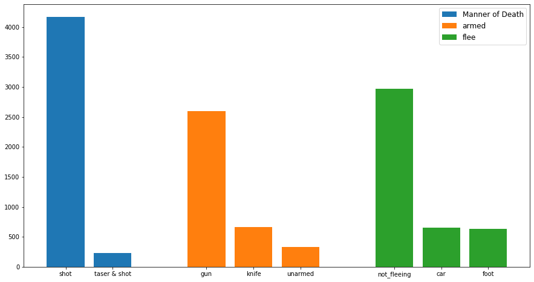

```python
f, ax = plt.subplots(1,1,figsize=(15,8))
ax.bar([1,2], [shot,taser], label = 'Manner of Death')
ax.bar([4,5,6], [gun,knife,unarmed], label = 'armed')
ax.bar([8,9,10], [not_fleeing,car,foot], label = 'flee')
ax.set_xticks([1,2,4,5,6,8,9,10])
ax.set_xticklabels(['shot','taser & shot','gun','knife','unarmed','not_fleeing','car','foot'])
ax.legend(fontsize=12)
print('Manner of Death: Shot({}) ,taser & shot({})\nArmed: gun({}), knife({}), unarmed({})\nFlee: not fleeing({}), car({}), foot({})'.format(shot,taser,gun,knife,unarmed,not_fleeing,car,foot))
```

We notice that in crime scenes police mainly shoot the offenders and that most of the offenders are armed with gun or knife. So we could asume that Police may were at self defence. From the other side we notice a significant big number of unarmed, or people that trying to flee with car or foot and get shot to death by Police, something that could considered abuse of power.

### City wise shootings

```python
shoot_city=data['city'].value_counts().to_frame().reset_index().rename(columns={'index':'city','city':'count'}).sort_values(by='count',ascending=False)

fig = go.Figure(go.Bar(
    x= shoot_city['city'][:20],
    y= shoot_city['count'][:20],
    text=shoot_city['count'][:20],
    textposition='outside',
    marker_color=shoot_city['count'][:20]
))

fig.update_xaxes(showline=True, linewidth=2, linecolor='black', mirror=True)
fig.update_yaxes(showline=True, linewidth=2, linecolor='black', mirror=True)
fig.update_layout(title_text='Fatal Killing - Top 20 Cities',xaxis_title='Cities',
                 yaxis_title='Total number of kills', title_x=0.5)
fig.show()
```

[interactive chart not shown]

```python
yearly_shooting_record_citywise = data[['city','year']]
yearly_shooting_record_citywise['kills'] = 1
yearly_shooting_record_citywise = yearly_shooting_record_citywise.groupby(['year','city']).sum()
yearly_shooting_record_citywise= yearly_shooting_record_citywise.reset_index()
yearly_shooting_record_citywise=yearly_shooting_record_citywise.sort_values(by=['year','kills'],ascending=False)
yearly_shooting_record_citywise
```

|  | year | city | kills |
| --- | --- | --- | --- |
| 3028 | 2020 | Houston | 6 |
| 2973 | 2020 | Columbus | 4 |
| 3033 | 2020 | Jacksonville | 4 |
| 3050 | 2020 | Las Vegas | 4 |
| 3109 | 2020 | Phoenix | 4 |
| ... | ... | ... | ... |
| 633 | 2015 | Yonkers | 1 |
| 634 | 2015 | York | 1 |
| 635 | 2015 | York County | 1 |
| 636 | 2015 | Zanesville | 1 |
| 637 | 2015 | Zion | 1 |

3190 rows × 3 columns

```python
city_shooting= pd.DataFrame(columns=['year','city','kills'])
for year in range(2015,2021):
    temp= yearly_shooting_record_citywise[yearly_shooting_record_citywise.year==year].iloc[0:1,:]
    city_shooting=city_shooting.append(temp,ignore_index=True)

fig = px.bar(city_shooting, y='kills', x='year',color='city', barmode='group')
fig.show()
```

[interactive chart not shown]

Los Angeles has seen some consistent amount of avgerage crime rate consecutively.

#### How Innocent people killed?

Here I have considered innocents who have no mental illness and are unarmed aswell as not trying to flee

```python
innocent_people = data[(data.signs_of_mental_illness==False) & (data.armed =='unarmed') & (data.flee=='Not fleeing')]
innocent_people = innocent_people['race'].value_counts()
innocent_people = pd.DataFrame(innocent_people)
innocent_people=  innocent_people.reset_index()
fig = px.pie(innocent_people, values='race', names='index', color_discrete_sequence=px.colors.sequential.RdBu)
print("total innocent Killed :",innocent_people['race'].sum())
fig.show()
```

```
total innocent Killed : 137
```

[interactive chart not shown]

People who were shot by the police who didn't have any signs of mental illness nor they were armed or fleeing from the police. we can see around 48% of White innocennts were shot down followed by blacks out of total of 137 innocents killed.

#### How Mental illness, threat level and manner of death plays the role

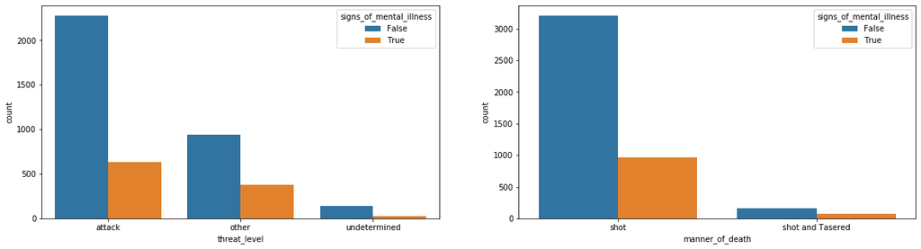

```python
fig, ax =plt.subplots(1, 2, figsize = (20, 5))
threat = data[["threat_level", "signs_of_mental_illness"]]
sns.countplot(data = threat, x = "threat_level", hue = "signs_of_mental_illness", ax = ax[0])
sns.countplot(data = data[["manner_of_death", "signs_of_mental_illness"]], x = "manner_of_death", hue = "signs_of_mental_illness")
```

### Conclusion:

#### 1. Analyse shooting w.r.t age and race of the victim?

[output not shown]

#### 2. Was the police shooting based on self defence or intended?

```
==> From the graphs above, we see police mainly shoot the offenders and that most of the offenders are             armed with gun or knife. So we could asume that Police may were at self defence. From the other side           we notice a significant big number of unarmed, or people that trying to flee with car or foot and get         shot to death by Police, something that could considered abuse of power.
```

#### 3. Cities with more shooting rate ?

```
==> Clearly Los Anglese,Pheonix and Houston have recorded the most number of deaths. Moreover Los Angeles         has consecutively maintain average shooting record over the span of 5 years.
```

#### 4. How did mental illness and threat level of victim affected the brutal shootings?

```
==> There was no abrupt increase in the number of people who were considerd a threat and they had any             underlying mental condition. One thing however I saw that the number of people who were not mentally ill           were mostly shot down as well as attacked.
```